# Water Quality Presentation 1

Group 3: Stephanie Fissel, Beza Gashe, Claire Yoon

January 3, 2023

# Problem

Access to safe drinking water is essential to health and a basic human right, though many developing countries and even parts of the U.S. like Flint, Michigan are living with contaminated drinking water. With the increased prevalence of climate change, drinking water is becoming even more negatively impacted by contaminants. In these instances, non-potable drinking water containing unsafe levels of contaminants can have serious adverse health effects, such as gastrointestinal illnesses, cancer, and transmissible diseases.

# Question

There are various water quality metrics that may contribute to the potability of drinking water. We want to analyze and determine what metrics may more heavily contribute to water being non-potable which could, in the real world, help formulate effective policy for health protection through implementation of systems that specifically de-contaminate the water of these substances. In some regions, it has been shown that investments in water supply and sanitation can yield a new economic benefit, since the reductions in adverse health effects and health care costs outweigh the costs of undertaking the interventions. Continuing with this idea, we can then answer the question, “How well can a Machine Learning model accurately predict the non-potability of water?”

# Data Source

### *[Water Quality](https://www.kaggle.com/datasets/adityakadiwal/water-potability?select=water_potability.csv)*

A dataset containing water quality metrics for 3276 different water bodies.  
Key metrics include:

- pH value
  - acidic or alkaline condition
- Hardness
  - caused by calcium and magnesium salts
- Solids (Total dissolved solids - TDS)
  - mineralization of organic minerals or salts
- Chloramines
  - disinfectant (chlorine + ammonia = chloramines)
- Sulfates
  - naturally occurring substance present in minerals, soil, and rocks
- Conductivity
  - determined by amount of dissolved solids
- Organic carbon
  - carbon in decaying natural organic matter and synthetic sources
- Trihalomethanes
  - chemicals found in water treated with chlorine
- Turbidity
  - depends on quantity of solid matter present; measure of light emitting properties of water

Target metric:

- Potability
  - indicator of whether water is safe for human consumption where 1 = Potable and 0 = Not Potable

#### Read in the data

```r
water_quality <- read.csv("/Users/stephaniefissel/Library/Mobile Documents/com~apple~CloudDocs/ds final project/water_potability.csv")

head(water_quality)
```

```
##         ph Hardness   Solids Chloramines  Sulfate Conductivity Organic_carbon
## 1       NA 204.8905 20791.32    7.300212 368.5164     564.3087      10.379783
## 2 3.716080 129.4229 18630.06    6.635246       NA     592.8854      15.180013
## 3 8.099124 224.2363 19909.54    9.275884       NA     418.6062      16.868637
## 4 8.316766 214.3734 22018.42    8.059332 356.8861     363.2665      18.436524
## 5 9.092223 181.1015 17978.99    6.546600 310.1357     398.4108      11.558279
## 6 5.584087 188.3133 28748.69    7.544869 326.6784     280.4679       8.399735
##   Trihalomethanes Turbidity Potability
## 1        86.99097  2.963135          0
## 2        56.32908  4.500656          0
## 3        66.42009  3.055934          0
## 4       100.34167  4.628771          0
## 5        31.99799  4.075075          0
## 6        54.91786  2.559708          0
```

### Clean the data

[output not shown]

#### Converting ‘Potability’ to a factor (categorical variable)

```r
water_quality$Potability <- factor(water_quality$Potability)
```

# Descriptive Statistics

## **SUMMARY STATS**

```r
st(water_quality)
```

Summary Statistics

| Variable | N | Mean | Std. Dev. | Min | Pctl. 25 | Pctl. 75 | Max |
| --- | --- | --- | --- | --- | --- | --- | --- |
| ph | 2011 | 7.086 | 1.573 | 0.227 | 6.09 | 8.053 | 14 |
| Hardness | 2011 | 195.968 | 32.635 | 73.492 | 176.745 | 216.441 | 317.338 |
| Solids | 2011 | 21917.441 | 8642.24 | 320.943 | 15615.665 | 27182.587 | 56488.672 |
| Chloramines | 2011 | 7.134 | 1.585 | 1.391 | 6.139 | 8.11 | 13.127 |
| Sulfate | 2011 | 333.225 | 41.205 | 129 | 307.633 | 359.331 | 481.031 |
| Conductivity | 2011 | 426.526 | 80.713 | 201.62 | 366.68 | 482.373 | 753.343 |
| Organic_carbon | 2011 | 14.358 | 3.325 | 2.2 | 12.124 | 16.683 | 27.007 |
| Trihalomethanes | 2011 | 66.401 | 16.077 | 8.577 | 55.953 | 77.292 | 124 |
| Turbidity | 2011 | 3.97 | 0.78 | 1.45 | 3.443 | 4.514 | 6.495 |
| Potability | 2011 |  |  |  |  |  |  |
| … 0 | 1200 | 59.7% |  |  |  |  |  |
| … 1 | 811 | 40.3% |  |  |  |  |  |

## **POTABLE VS. NON-POTABLE**

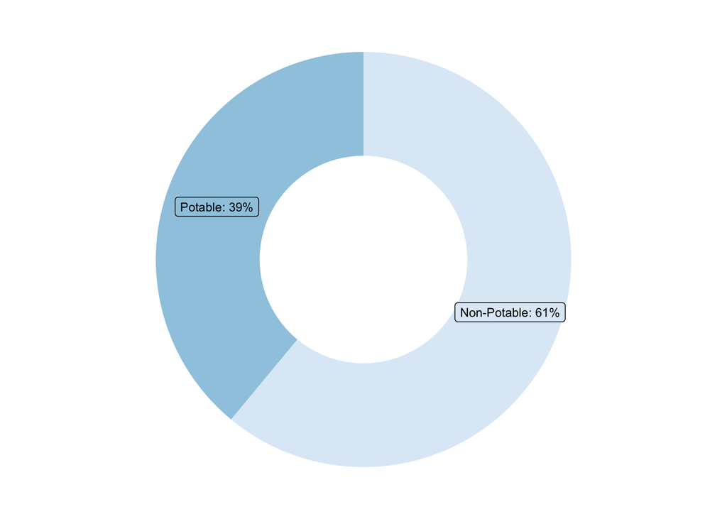

```r
# non-potable
# colSums(water_quality==0) #--> 1998
# potable
# colSums(water_quality==1) #--> 1278
np <- round(1998/3276 * 100)
p <- round(1278/3276 * 100)
# Subset test data
data <- data.frame(
  category=c("Non-Potable", "Potable"),
  count=c(np, p)
)

# Compute percentages
data$fraction = data$count / sum(data$count)

# Compute the cumulative percentages (top of each rectangle)
data$ymax = cumsum(data$fraction)

# Compute the bottom of each rectangle
data$ymin = c(0, head(data$ymax, n=-1))

# Compute label position
data$labelPosition <- (data$ymax + data$ymin) / 2

# Compute a good label
data$label <- paste0(data$category, ": ", data$count, "%")

# Make the plot
ggplot(data, aes(ymax=ymax, ymin=ymin, xmax=4, xmin=3, fill=category)) +
  geom_rect() +
  geom_label( x=3.5, aes(y=labelPosition, label=label), size=3) +
  scale_fill_brewer(palette=1) +
  coord_polar(theta="y") +
  xlim(c(2, 4)) +
  theme_void() +
  theme(legend.position = "none")
```

## **DISTRIBUTIONS**

### pH

**Recommended Level:** 6.5-8.5 pH (neutral on pH scale)

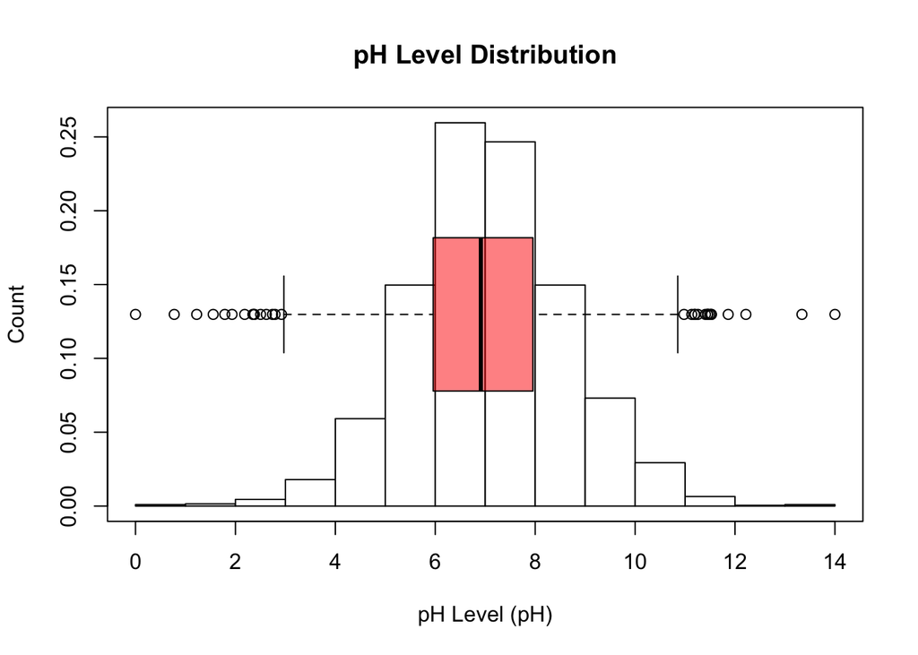

```r
# Histogram
hist(water_quality$ph, prob = TRUE,
     col = "white",
     main = "pH Level Distribution",
     xlab = "pH Level (pH)",
     ylab = "Count")

# Add new plot
par(new = TRUE)

# Box plot
boxplot(water_quality$ph, horizontal = TRUE, axes = FALSE,
        col = rgb(1, 0, 0, alpha = 0.5))

# Box around the plots
box()
```

### Hardness

**Recommended Level:** None  
Hardness levels > 150 mg/L are considered hard water. If water is hard, it can reduce efficiency of water treatment.

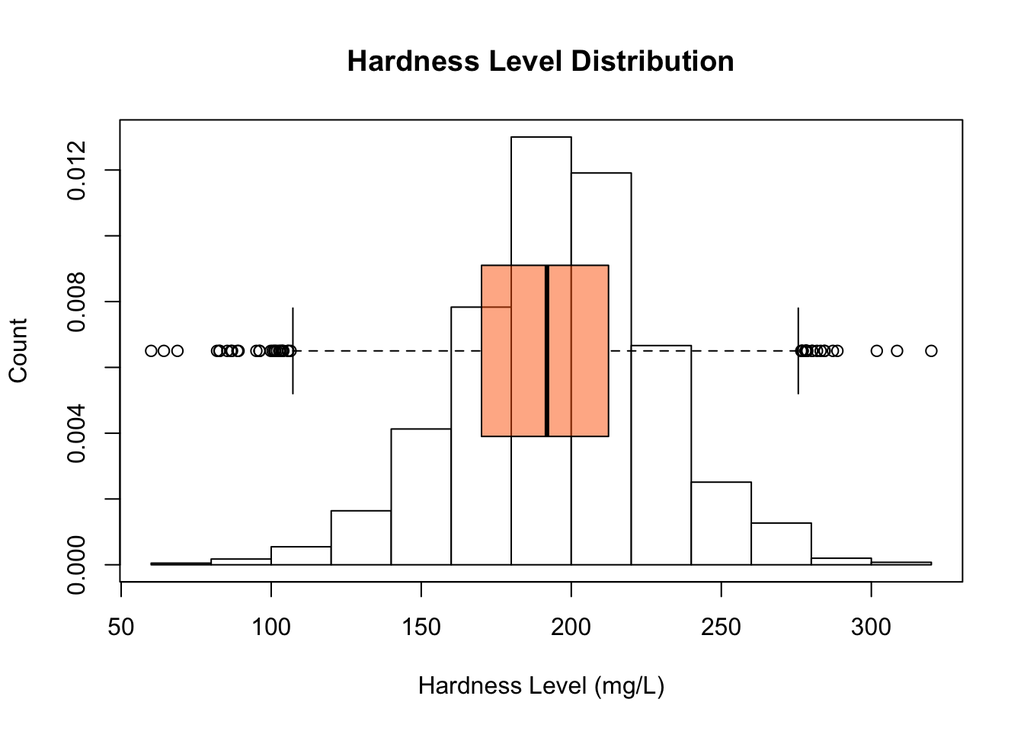

```r
# Histogram
hist(water_quality$Hardness, prob = TRUE,
     col = "white",
     main = "Hardness Level Distribution",
     xlab = "Hardness Level (mg/L)",
     ylab = "Count")

# Add new plot
par(new = TRUE)

# Box plot
boxplot(water_quality$Hardness, horizontal = TRUE, axes = FALSE,
        col = rgb(1, 0.4, 0, alpha = 0.5))

# Box around the plots
box()
```

### Solids

**Recommended Level:** 500-1000 mg/l

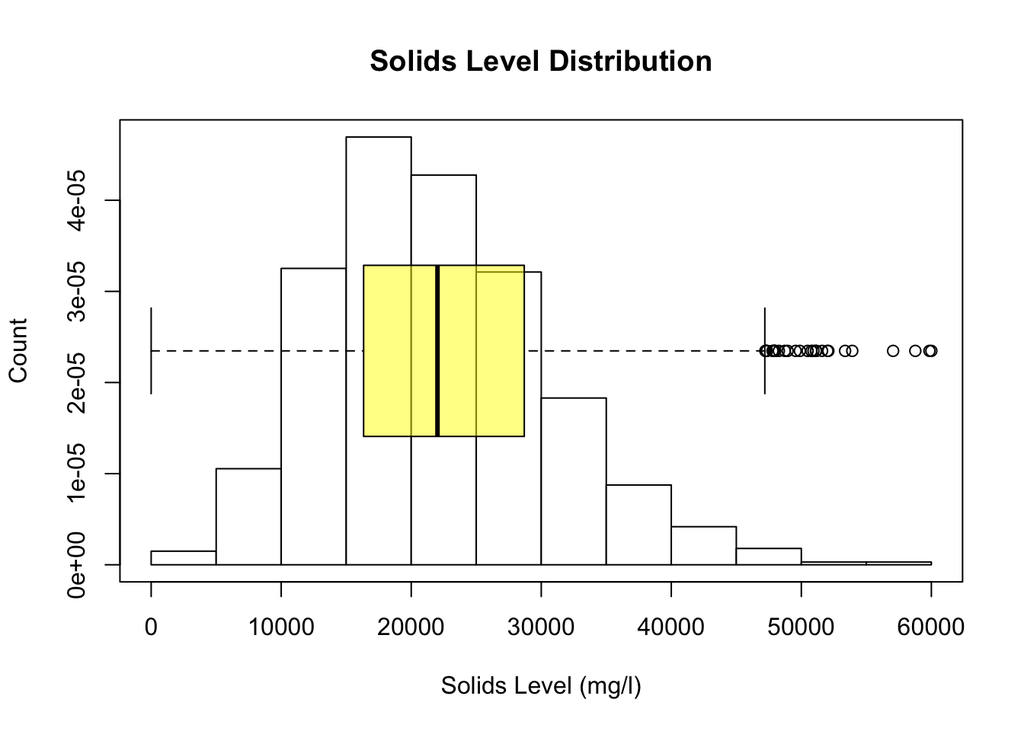

```r
# Histogram
hist(water_quality$Solids, prob = TRUE,
     col = "white",
     main = "Solids Level Distribution",
     xlab = "Solids Level (mg/l)",
     ylab = "Count")

# Add new plot
par(new = TRUE)

# Box plot
boxplot(water_quality$Solids, horizontal = TRUE, axes = FALSE,
        col = rgb(1, 1, 0, alpha = 0.5))

# Box around the plots
box()
```

### Chloramines

**Recommended Level:** 4 mg/L or less

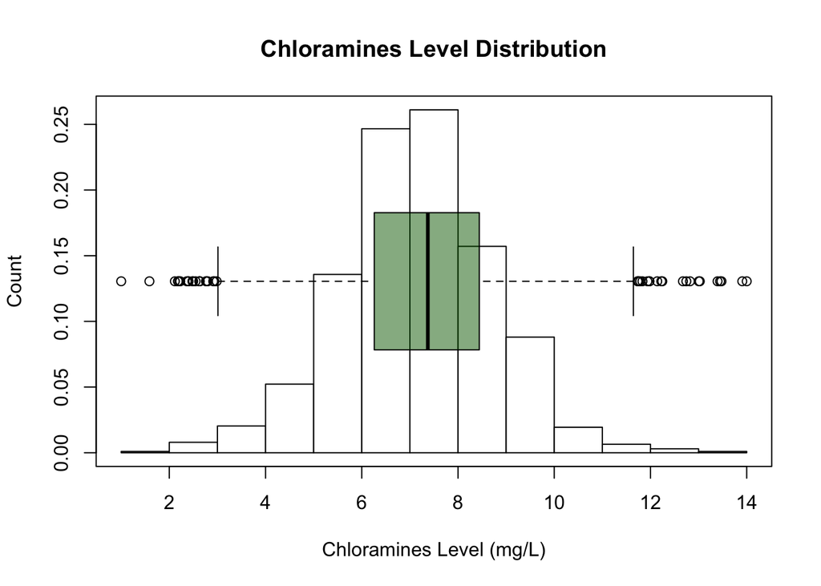

```r
# Histogram
hist(water_quality$Chloramines, prob = TRUE,
     col = "white",
     main = "Chloramines Level Distribution",
     xlab = "Chloramines Level (mg/L)",
     ylab = "Count")

# Add new plot
par(new = TRUE)

# Box plot
boxplot(water_quality$Chloramines, horizontal = TRUE, axes = FALSE,
        col = rgb(0, 0.4, 0, alpha = 0.5))

# Box around the plots
box()
```

### Conductivity

**Recommended Level:** 400 μS/cm or less

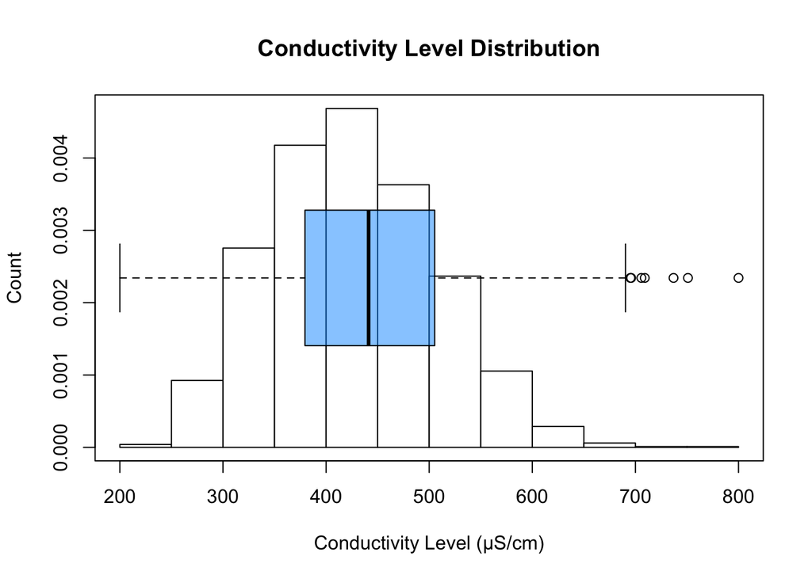

```r
# Histogram
hist(water_quality$Conductivity, prob = TRUE,
     col = "white",
     main = "Conductivity Level Distribution",
     xlab = "Conductivity Level (μS/cm)",
     ylab = "Count")

# Add new plot
par(new = TRUE)

# Box plot
boxplot(water_quality$Conductivity, horizontal = TRUE, axes = FALSE,
        col = rgb(0, 0.6, 1, alpha = 0.5))

# Box around the plots
box()
```

### Organic Carbon

**Recommended Level:** 2 mg/L or less

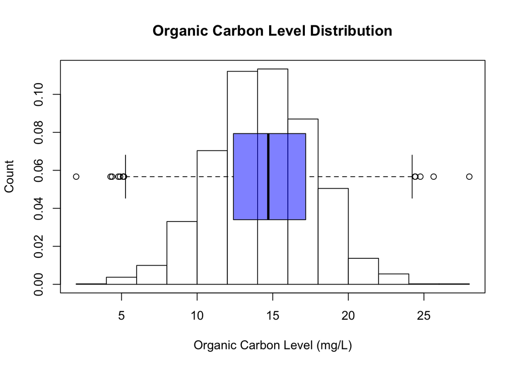

```r
# Histogram
hist(water_quality$Organic_carbon, prob = TRUE,
     col = "white",
     main = "Organic Carbon Level Distribution",
     xlab = "Organic Carbon Level (mg/L)",
     ylab = "Count")

# Add new plot
par(new = TRUE)

# Box plot
boxplot(water_quality$Organic_carbon, horizontal = TRUE, axes = FALSE,
        col = rgb(0, 0.2, 1, alpha = 0.5))

# Box around the plots
box()
```

### Trihalomethanes

**Recommended Level:** 80 ppm or less

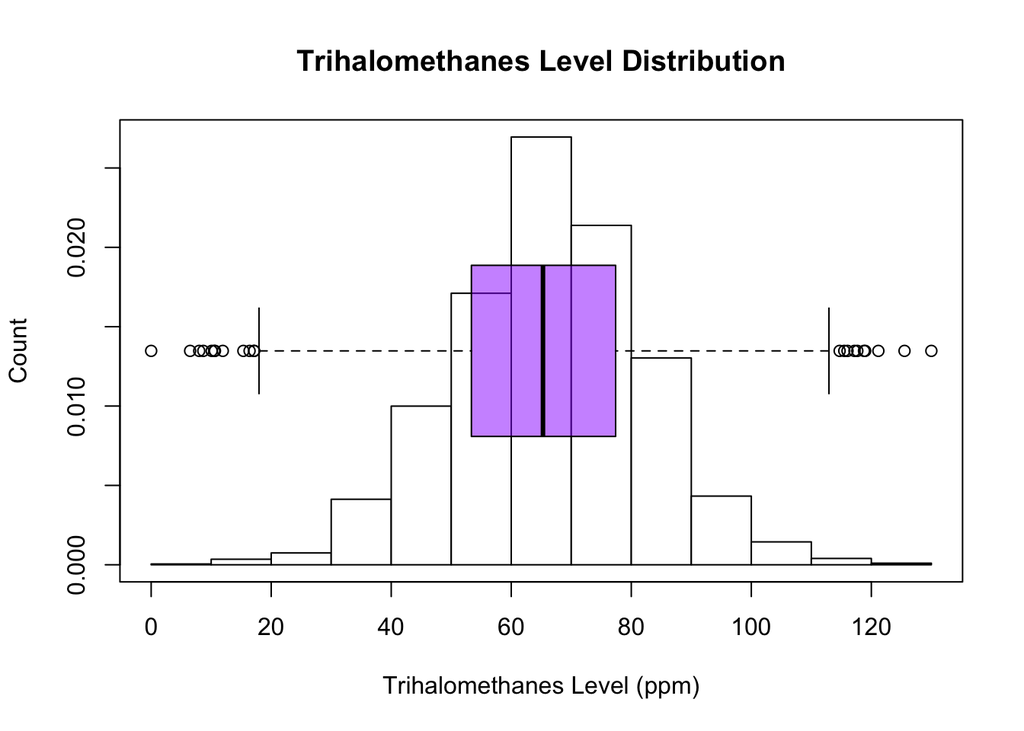

```r
# Histogram
hist(water_quality$Trihalomethanes, prob = TRUE,
     col = "white",
     main = "Trihalomethanes Level Distribution",
     xlab = "Trihalomethanes Level (ppm)",
     ylab = "Count")

# Add new plot
par(new = TRUE)

# Box plot
boxplot(water_quality$Trihalomethanes, horizontal = TRUE, axes = FALSE,
        col = rgb(0.6, 0, 1, alpha = 0.5))

# Box around the plots
box()
```

### Turbidity

**Recommended Level:** 5 NTU or less

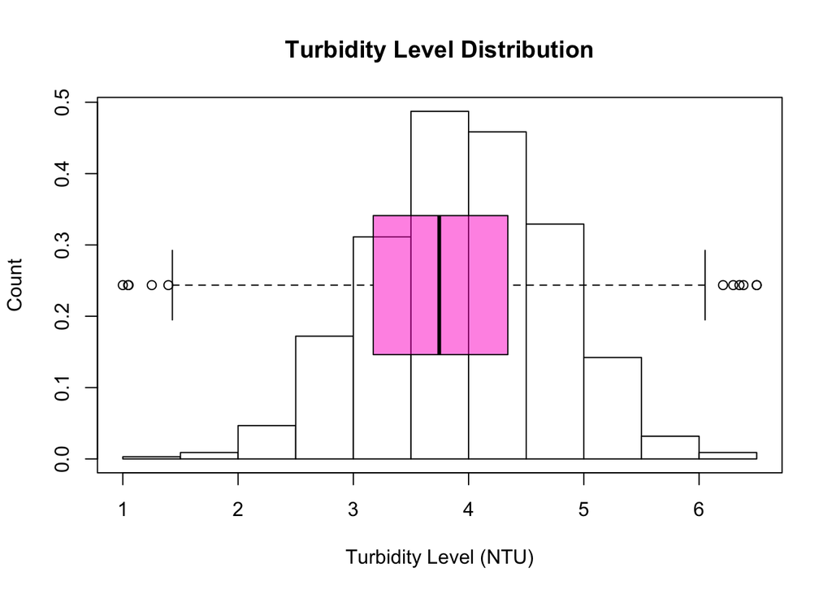

```r
# Histogram
hist(water_quality$Turbidity, prob = TRUE,
     col = "white",
     main = "Turbidity Level Distribution",
     xlab = "Turbidity Level (NTU)",
     ylab = "Count")

# Add new plot
par(new = TRUE)

# Box plot
boxplot(water_quality$Turbidity, horizontal = TRUE, axes = FALSE,
        col = rgb(1, 0.2, 0.8, alpha = 0.5))

# Box around the plots
box()
```